# Study 3

## Summaries

```
## # A tibble: 3 x 5
##   method     variable            n  mean    sd
##   <fct>      <chr>           <dbl> <dbl> <dbl>
## 1 AR         completion_time    20 2137.  682.
## 2 PHYSICAL   completion_time    20 1774.  661.
## 3 RL_CLUSTER completion_time    20 2268.  897.
```

The next set of results show the number of correct responses grouped by method.

```
##      Group.1  x
## 1         AR 91
## 2   PHYSICAL 87
## 3 RL_CLUSTER 84
```

## Rate Correct Score

To analyse both error rates and completion times together, we use the RATE CORRECT SCORE (“A Comparison of Methods to Combine Speed and Accuracy Measures of Performance: a rejoining on the binning procedure” - Andre Vandierendonck).

RCS = #correct responses / average response time

and can be interpreted as the number of correct responses per second of task activity. (this value has been square root transformed).

```
## # A tibble: 3 x 5
##   method     variable     n  mean    sd
##   <fct>      <chr>    <dbl> <dbl> <dbl>
## 1 AR         rcs         20 0.046 0.014
## 2 PHYSICAL   rcs         20 0.051 0.012
## 3 RL_CLUSTER rcs         20 0.044 0.021
```

## ASSUMPTION TESTING

### Normality test using Shapiro-wilk test.

Completion Times

```r
my_data %>% group_by(method) %>% shapiro_test(completion_time);
```

```
## # A tibble: 3 x 4
##   method     variable        statistic      p
##   <fct>      <chr>               <dbl>  <dbl>
## 1 AR         completion_time     0.966 0.672
## 2 PHYSICAL   completion_time     0.913 0.0714
## 3 RL_CLUSTER completion_time     0.927 0.135
```

RCS

```r
my_data %>% group_by(method) %>% shapiro_test(rcs);
```

```
## # A tibble: 3 x 4
##   method     variable statistic       p
##   <fct>      <chr>        <dbl>   <dbl>
## 1 AR         rcs          0.825 0.00206
## 2 PHYSICAL   rcs          0.948 0.342
## 3 RL_CLUSTER rcs          0.904 0.0500
```

Error Rate is not presented as it is not normal

### Homogeneity of Variances using Levene’s test.

Completion Times

```r
leveneTest(my_data$completion_time~my_data$method);
```

```
## Levene's Test for Homogeneity of Variance (center = median)
##       Df F value Pr(>F)
## group  2  0.2952 0.7455
##       57
```

RCS

```r
leveneTest(my_data$rcs~my_data$method);
```

```
## Levene's Test for Homogeneity of Variance (center = median)
##       Df F value Pr(>F)
## group  2  1.0342 0.3621
##       57
```

### QQ-plots

Completion Time

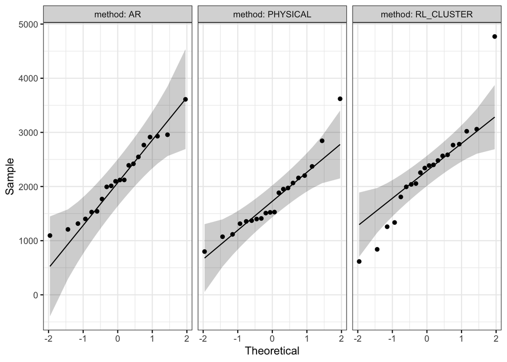

RCS

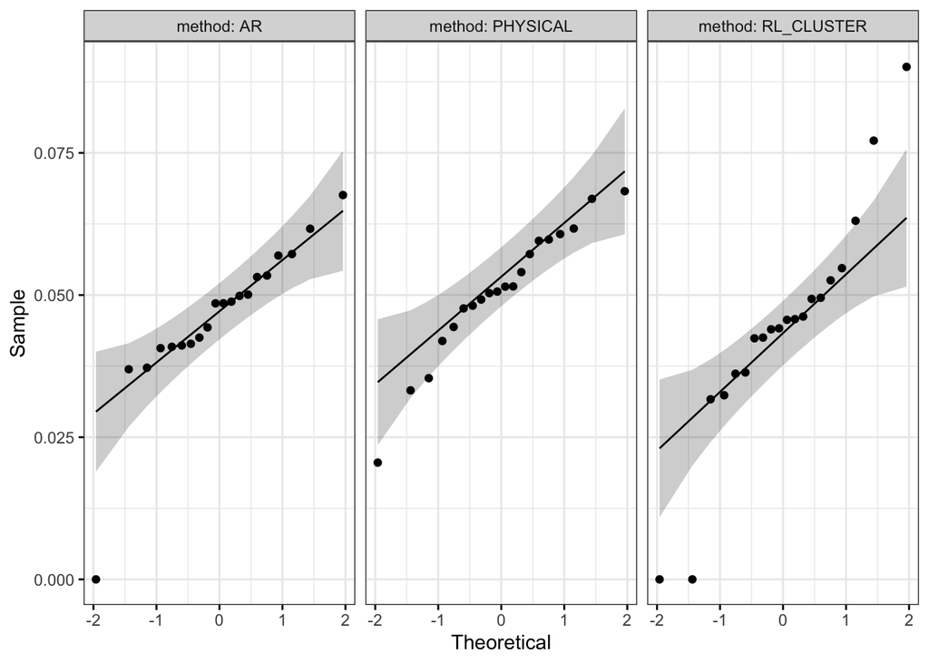

## ANOVA

Completion Time

```r
ezANOVA(data = my_data, dv = .(completion_time), wid = .(pid), between = .(method), type = 3, detailed = T);
```

```
## $ANOVA
##        Effect DFn DFd       SSn      SSd          F            p p<.05
## 1 (Intercept)   1  57 254491170 32430540 447.294326 1.156504e-28     *
## 2      method   2  57   2624375 32430540   2.306304 1.088554e-01
##          ges
## 1 0.88697077
## 2 0.07486469
##
## $`Levene's Test for Homogeneity of Variance`
##   DFn DFd      SSn      SSd         F         p p<.05
## 1   2  57 163130.1 15748295 0.2952197 0.7454993
```

RCS

```r
ezANOVA(data = my_data, dv = .(rcs), wid = .(pid), between = .(method), type = 3, detailed = T);
```

```
## $ANOVA
##        Effect DFn DFd          SSn       SSd           F            p p<.05
## 1 (Intercept)   1  57 0.1322739218 0.0142271 529.9473970 1.516525e-30     *
## 2      method   2  57 0.0004392907 0.0142271   0.8799956 4.203435e-01
##         ges
## 1 0.9028874
## 2 0.0299522
##
## $`Levene's Test for Homogeneity of Variance`
##   DFn DFd          SSn        SSd        F        p p<.05
## 1   2  57 0.0002874128 0.00792009 1.034239 0.362071
```

Removing the outliers from the data does not change the ANOVA results.

```r
outlier_discard <- c(2,11,28,34,39,64)
my_data_outlier_discarded <- my_data[!(my_data$pid %in% outlier_discard),]

ezANOVA(data = my_data_outlier_discarded, dv = .(rcs), wid = .(pid), between = .(method), type = 3, detailed = T);
```

```
## $ANOVA
##        Effect DFn DFd          SSn        SSd           F            p p<.05
## 1 (Intercept)   1  51 0.1261175911 0.00393464 1634.710253 2.053605e-40     *
## 2      method   2  51 0.0004810657 0.00393464    3.117737 5.279280e-02
##         ges
## 1 0.9697457
## 2 0.1089442
##
## $`Levene's Test for Homogeneity of Variance`
##   DFn DFd          SSn         SSd         F         p p<.05
## 1   2  51 1.343495e-05 0.001517232 0.2258002 0.7986709
```

## KRUSKAL-WALLIS

```r
kruskal.test(rcs~method, data = my_data)
```

```
##
##  Kruskal-Wallis rank sum test
##
## data:  rcs by method
## Kruskal-Wallis chi-squared = 3.38, df = 2, p-value = 0.1845
```

## ANCOVA - COMPLETION TIME

### Assumptions

#### Linearity Assumption

Completion Time vs Age

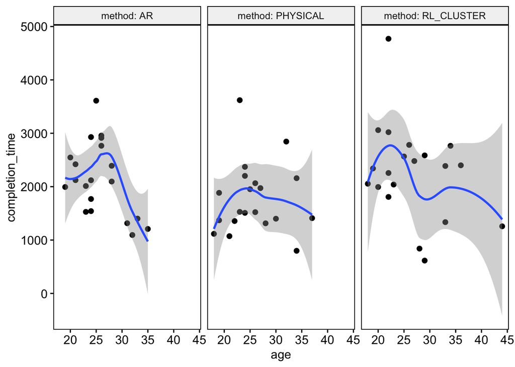

The other covariates (gender, education, mid-air, problem solving) are categorical and plotting their data to assess their linearity does not make sense.

#### Homogeneity of Regression Slopes

According to https://www.datanovia.com/en/lessons/ancova-in-r/, the test for homogeniety of regression slopes is an ANOVA with the covariates coming in first (age, gender, education, mid-air, problem solving) then the grouping variable (method) and then every combination of intearations.

```r
my_data %>%
  anova_test(completion_time ~
               age +
               gender +
               education +
               mid_air +
               problem_solving +
               method +
               age * method +
               gender * method +
               education * method +
               mid_air * method +
               problem_solving * method +
               age * gender * method +
               age * education * method +
               age * mid_air * method +
               age * problem_solving * method +
               gender * education * method +
               gender * mid_air * method +
               gender * problem_solving * method +
               education * mid_air * method +
               education * problem_solving * method +
               mid_air * problem_solving * method +
               age * gender * education * method +
               age * gender * mid_air * method +
               age * gender * problem_solving * method +
               age * education * mid_air * method +
               age * education * problem_solving * method +
               age * mid_air * problem_solving * method +
               gender * education * mid_air * method +
               gender * education * problem_solving * method +
               gender * mid_air * problem_solving * method +
               education * mid_air * problem_solving * method +
               age * gender * education * mid_air * problem_solving * method)
```

```
## Coefficient covariances computed by hccm()
```

```
## Note: model has aliased coefficients
##       sums of squares computed by model comparison
```

```
## ANOVA Table (type II tests)
##
##                                                 Effect DFn DFd       F     p
## 1                                                  age   1   6   3.934 0.095
## 2                                               gender   1   6   0.184 0.683
## 3                                            education   3   6   0.260 0.852
## 4                                              mid_air   1   6   0.317 0.594
## 5                                      problem_solving   1   6   1.190 0.317
## 6                                               method   2   6   2.154 0.197
## 7                                           age:method   2   6   0.965 0.433
## 8                                        gender:method   0   6      NA    NA
## 9                                     education:method   2   6   0.404 0.685
## 10                                      mid_air:method   0   6      NA    NA
## 11                              problem_solving:method   1   6   2.681 0.153
## 12                                          age:gender   1   6   2.070 0.200
```

[output cut: 115 more lines]

This does not make much sense to me as using (age * gender * education * mid_air * problem_solving * method) should give the same results but Senuri mentioned that order matters which is why the above monstrosity was constructed.

Regression slope for completion time and age seems to deviate from the rest.

#### Normality

Completion Times normality test using shapiro-wilk test. No significant results

```
## # A tibble: 1 x 3
##   variable                statistic p.value
##   <chr>                       <dbl>   <dbl>
## 1 model.ct.metrics$.resid     0.972   0.181
```

#### Homogeneity of variances

Completion Times Homogeneity of variances test using levene’s test. No significant results.

```
## # A tibble: 1 x 4
##     df1   df2 statistic     p
##   <int> <int>     <dbl> <dbl>
## 1     2    57     0.687 0.507
```

#### Outliers

```
##   .rownames completion_time age gender education mid_air problem_solving
## 1        46        4770.451  22      F bachelors       0               1
##       method   .resid  .cooksd .std.resid
## 1 RL_CLUSTER 2386.656 0.160558   3.350104
```

#### Computation

ANCOVA

DV = completion time, IV = method, covariates = age, gender, education, mid_air, problem_solving, method

```r
res.aov <- my_data %>%
  anova_test(completion_time ~ age + gender + education + mid_air + problem_solving + method, type = 2)
```

```
## Coefficient covariances computed by hccm()
```

```r
get_anova_table(res.aov)
```

```
## ANOVA Table (type II tests)
##
##            Effect DFn DFd     F     p p<.05      ges
## 1             age   1  50 0.711 0.403       0.014000
## 2          gender   1  50 0.043 0.837       0.000858
## 3       education   3  50 0.251 0.860       0.015000
## 4         mid_air   1  50 0.669 0.417       0.013000
## 5 problem_solving   1  50 0.546 0.463       0.011000
## 6          method   2  50 2.103 0.133       0.078000
```

## ANCOVA - RCS

### Assumptions

#### Linearity Assumption

RCS vs Age

[figure not shown]

The other covariates (gender, education, mid-air, problem solving) are categorical and plotting their data to assess their linearity does not make sense.

#### Homogeneity of Regression Slopes

According to https://www.datanovia.com/en/lessons/ancova-in-r/, the test for homogeniety of regression slopes is an ANOVA with the covariates coming in first (age, gender, education, mid-air, problem solving) then the grouping variable (method) and then every combination of intearations.

```r
my_data %>%
  anova_test(rcs ~
               age +
               gender +
               education +
               mid_air +
               problem_solving +
               method +
               age * method +
               gender * method +
               education * method +
               mid_air * method +
               problem_solving * method +
               age * gender * method +
               age * education * method +
               age * mid_air * method +
               age * problem_solving * method +
               gender * education * method +
               gender * mid_air * method +
               gender * problem_solving * method +
               education * mid_air * method +
               education * problem_solving * method +
               mid_air * problem_solving * method +
               age * gender * education * method +
               age * gender * mid_air * method +
               age * gender * problem_solving * method +
               age * education * mid_air * method +
               age * education * problem_solving * method +
               age * mid_air * problem_solving * method +
               gender * education * mid_air * method +
               gender * education * problem_solving * method +
               gender * mid_air * problem_solving * method +
               education * mid_air * problem_solving * method +
               age * gender * education * mid_air * problem_solving * method)
```

```
## Coefficient covariances computed by hccm()
```

```
## Note: model has aliased coefficients
##       sums of squares computed by model comparison
```

```
## ANOVA Table (type II tests)
##
##                                                 Effect DFn DFd         F     p
## 1                                                  age   1   6  0.024000 0.881
## 2                                               gender   1   6  0.363000 0.569
## 3                                            education   3   6  1.653000 0.274
## 4                                              mid_air   1   6  0.591000 0.471
## 5                                      problem_solving   1   6  0.006000 0.941
## 6                                               method   2   6  4.717000 0.059
## 7                                           age:method   2   6  0.201000 0.823
## 8                                        gender:method   0   6        NA    NA
## 9                                     education:method   2   6  1.630000 0.272
## 10                                      mid_air:method   0   6        NA    NA
## 11                              problem_solving:method   1   6  1.270000 0.303
## 12                                          age:gender   1   6 18.772000 0.005
```

[output cut: 115 more lines]

This does not make much sense to me as using (age * gender * education * mid_air * problem_solving * method) should give the same results but Senuri mentioned that order matters which is why the above monstrosity was constructed.

#### Normality

rcs normality test using shapiro-wilk test. SIGNIFICANT RESULTS

```
## # A tibble: 1 x 3
##   variable                 statistic   p.value
##   <chr>                        <dbl>     <dbl>
## 1 model.rcs.metrics$.resid     0.886 0.0000409
```

#### Homogeneity of variances

```
## # A tibble: 1 x 4
##     df1   df2 statistic     p
##   <int> <int>     <dbl> <dbl>
## 1     2    57      2.32 0.108
```

#### Outliers

```
##   .rownames        rcs age gender education mid_air problem_solving     method
## 1        11 0.09012243  29      M   masters       1               1 RL_CLUSTER
##       .resid   .cooksd .std.resid
## 1 0.04649783 0.1918998   3.181353
```

#### Computation

ANCOVA

DV = rcs, IV = method, covariates = age, gender, education, mid_air, problem_solving, method

```r
res.aov <- my_data %>%
  anova_test(rcs ~ age + gender + education + mid_air + problem_solving + method, type = 2)
```

```
## Coefficient covariances computed by hccm()
```

```r
get_anova_table(res.aov)
```

```
## ANOVA Table (type II tests)
##
##            Effect DFn DFd     F     p p<.05      ges
## 1             age   1  50 0.002 0.966       3.71e-05
## 2          gender   1  50 0.134 0.716       3.00e-03
## 3       education   3  50 1.151 0.338       6.50e-02
## 4         mid_air   1  50 0.414 0.523       8.00e-03
## 5 problem_solving   1  50 0.821 0.369       1.60e-02
## 6          method   2  50 1.123 0.333       4.30e-02
```